# Replicating graphs in Goyal and Welch 2008 (RFS)

[www.PedramJahangiry.com](https://sites.google.com/site/jahangirypedram/)

Last update: August, 2016

Here is how one can replicate the graphs in Goyal and Welch 2008 (RFS) paper. Note that everything is summarized in a function called Annual_predictability with the following arguments.

- **LHS** is the Left Hand Side variable which can be either “SP500” , “ERP” : Equity Risk Premium, or “CRSP_SPvw”
- **RHS** is the Right Hand Side variable which is selected from the following variables:
  - “ep” : earning per share ratio
  - “dp” : dividend price ratio
  - “dy” : dividend yield ratio
  - “cay” : consumption wealth ratio using Goyal and Welch data
  - “svar” : Stock Variance
  - “csp” : Cross-Sectional Premium
  - “b.m” : Book to Market ratio
  - “ntis” : Net Equity Expansion
  - “eqis” : Percent Equity Issuing
  - “tbl” : Treasury Bills
  - “lyt”: Long Term Yield
  - “ltr”: Long Term Rate of Returns
  - “infl” : inflation
  - “ik” : Investment to Capital Ratio
- **multi_RHS** is a combination of any two or more single RHS variables. For example a combination of two variables: c(“dp”,“cay”)
- **start_date** and **end_date** are simply the start and end dates of observations in a yyyy format. like 2015, 1890 and etc
- **H** is the overlapping horizon for instance H=20 or H=10 and etc.
- **OOS_est_period** is the out of sample estimation periods is the number of periods used for out of sample estimations

Let’s start with loading some data, you can find the original data from Amit Goyal’s [website](http://www.hec.unil.ch/agoyal/).

```r
Data_source  <- "./modified_data.csv"
A_df         <- tbl_df(read.table(Data_source, sep = ",", header = TRUE) )
```

And here is the function:

```r
Annual_predictability  <- function(df=A_df, LHS="ERP", RHS="dp", multi_RHS=c("dp", "dy"),
                                   start_date=1872, end_date=2005, H=1, OOS_est_period=20){



        # constructing filtered data set and required variables
        A            <- as.data.frame(filter(df, year>=start_date & year<=end_date))
        T            <- nrow(A)  # Number of time periods

        reg_single_OLS <- list()  # this is where we store single   regression results (OLS)
        reg_single_NW  <- list()  # this is where we store single   regression results (NW corrected ones)
        reg_multi_OLS  <- list()  # this is where we store multiple regression results (OLS)
        reg_multi_NW   <- list()  # this is where we store multiple regression results (NW corrected ones)



        # out of sample variables
        IS_error_N     <- data.frame(stat=rep("IS_e_N", T-H+1), year=(start_date):(end_date-H+1))
        IS_error_A     <- data.frame(stat=rep("IS_e_A", T-H), year=(start_date+1):(end_date-H+1))

        OOS_error_N    <- data.frame(stat=rep("OOS_e_N", T-H+1- OOS_est_period),
                                     year=(start_date+ OOS_est_period) :(end_date-H+1))
        OOS_error_N    <- data.frame(stat=rep("OOS_e_N",T-H++2- OOS_est_period),
                                     year=(start_date+ OOS_est_period-1) :(end_date-H+1))
        OOS_error_A    <- data.frame(stat=rep("OOS_e_A", T-H+2- OOS_est_period),
                                     year=(start_date+ OOS_est_period-1) :(end_date-H+1))
        OOS_error_AR   <- data.frame(stat=rep("OOS_e_AR",T-H+2- OOS_est_period),
                                     year=(start_date+ OOS_est_period-1) :(end_date-H+1))


        IS_CSSE        <- data.frame(year=(start_date+1) :(end_date-H+1), stat=rep("IS_CSSE",T-H))
        # this is IS cumulative SSE

        OOS_CSSE       <- data.frame(year=(start_date+ OOS_est_period-1) :(end_date-H+1),
                                     stat=rep("OOS_CSSE",T-H+2- OOS_est_period ))
        # this is OOS cumulative SSE

        # regressions of mean returns on predicting factor = RHS
        # making mean returns
        for(j in 1:H){
                LHS_ret <- c()
                for (i in 1:(T-j+1)){ LHS_ret[i]  <-  mean(A[i:(i+j-1),LHS]) }

                # regressions and statistics
                reg_H                  <- lm(LHS_ret~lag(A[1:(T-j+1),RHS],1))

                #storing single regressions results for H horizons
                reg_single_OLS[[j]]    <- reg_H
                reg_single_NW[[j]]     <- coeftest(reg_H, vcov = NeweyWest)

                # multiple regressions , pick what predictors you want to include here
                multi_tag              <- multi_RHS # this must be at leat 2 variables
                reg_multi              <- lm(LHS_ret ~ sapply(A[1:(T-j+1), multi_tag], lag))
                reg_multi_OLS[[j]]     <- reg_multi
                reg_multi_NW[[j]]      <- coeftest(reg_multi, vcov = NeweyWest)
        }



        # Generating out of sample tests for H-year horizon

        #In Sample (IS)
        #1. Historical mean model
        IS_LHS           <- as.matrix(LHS_ret[1:(T-H+1)])
        IS_error_N$error <- IS_LHS - mean(IS_LHS, na.rm=TRUE)


        #2. OLS model
        reg              <- lm(LHS_ret~lag(A[1:(T-H+1),RHS],1))
        IS_error_A$error <- reg$residuals
        IS_R2            <- summary(reg)$r.squared
        IS_adj.R2        <- summary(reg)$adj.r.squared


        # OUT-of-Sample (OOS) : Only use information that is available up to the time at which
        # the forecast is made
        temp_e_N      <- c()   # temporary errors of historical mean benchmark model
        temp_e_A      <- c()   # temporary errors of  Alternative (conditional) model
        temp_e_AR     <- c()   # temporary errors of Auto regressive benchmark model

        for (s in (1 + OOS_est_period ):(T-H+1)) {

                #1. Historical mean model , with (s-1) observation we estimate the numbers for _[s]
                OOS_LHS            <- as.matrix(LHS_ret)
                temp_e_N[s]        <- OOS_LHS[s] - mean(OOS_LHS[1:(s-1)])

                #2. AR benchmart
                reg_OOS_AR         <- lm(OOS_LHS[1:(s-1)]~lag(OOS_LHS[1:(s-1)],1))
                temp_e_AR[s]       <- (coef(reg_OOS_AR)[1]+coef(reg_OOS_AR)[2]*A[(s-1),RHS])  - OOS_LHS[s]


                #3. OLS model
                reg_OOS            <- lm(OOS_LHS[1:(s-1)]~lag(A[1:(s-1),RHS],1))
                temp_e_A[s]        <-  (coef(reg_OOS)[1]+coef(reg_OOS)[2]*A[(s-1),RHS])  - OOS_LHS[s]
        }

        # errors in the first period after est_period = 0 for all 3 models. (we loose 1 observation)
        OOS_error_N$error    <- as.matrix( c(0, temp_e_N[(1 + OOS_est_period):(T-H+1)]))
        OOS_error_A$error    <- as.matrix( c(0, temp_e_A[(1+ OOS_est_period):(T-H+1)]) )
        OOS_error_AR$error   <- as.matrix( c(0, temp_e_AR[(1 + OOS_est_period):(T-H+1)]))

        # constructing Goyal and Welch OOS tests
        T_OOS      <- T-H+1- OOS_est_period             # T is the total number of forecast observations
        h          <- H                                # h is the overlap degree

        MSE_N      <- mean(OOS_error_N$error^2)
        MSE_A      <- mean(OOS_error_A$error^2)
        MSE_AR     <- mean(OOS_error_AR$error^2)
        OOS_R2     <- 1 - MSE_A/MSE_N
        delta_MAE  <- sum((abs(OOS_error_N$error)-abs(OOS_error_A$error)))/T_OOS
        delta_RMSE <- sqrt(MSE_N) - sqrt(MSE_A)
        d          <-  OOS_error_N$error - OOS_error_A$error
        MSE_T      <- sqrt(T_OOS + 1 - 2* h + h*(h-1)/T_OOS) * (mean(d)/sqrt(var(d)))
        MSE_F      <- (T_OOS - h +1) * ((MSE_N-MSE_A)/MSE_A)
        ENC        <- ((T_OOS-h+1)/T_OOS) *
                sum(OOS_error_N$error^2 - OOS_error_N$error * OOS_error_A$error ) / MSE_A


        # Cumulative SSE difference

        IS_CSSE$CSSE  <- cumsum(IS_error_N[-1,"error"]^2)-cumsum(IS_error_A[,"error"]^2)
        OOS_CSSE$CSSE <- cumsum(OOS_error_N[,"error"]^2)-cumsum(OOS_error_A[,"error"]^2)

        df1_IS   <- data.frame(x=(start_date+1) :(end_date-H+1), y=IS_CSSE$CSSE , df_name= "IS" )
        df1_IS$y <- df1_IS$y - df1_IS$y[OOS_est_period-1]
        #Because we lose one observation due to the lag we Shift IS errors vertically, so that the IS line begins at zero on the date of first OOS prediction. (Goyal/Welch (2008, p. 1465))


        df2_OOS   <- data.frame(x=(start_date+ OOS_est_period-1) :(end_date-H+1),y=OOS_CSSE$CSSE,
                                df_name="OOS" )
        df_OOS    <- rbind(df1_IS,df2_OOS)

        # Plotting OOS vs IS cumulative SSE (replicating Goyal and Welch 2008 graphs)
        p_OOS    <-   ggplot(df_OOS, aes(y=y, x=x, color= df_name)) + geom_line(size=1)+
                labs(x = paste("YEAR ", "( OOS Estimation Period =",OOS_est_period ,", H=",H,  ")",sep=" " ),
                     y="Cumulative SSE Difference", color=paste("(",LHS,",", RHS,")", sep=" " ))+
                geom_hline(aes(yintercept=0))+
                coord_cartesian( ylim = c(-0.2,0.2))




        # Plotting H-Horizon returns vs predictors (replicating Lettau Ludvigson 2001 graphs)
        if (RHS=="dsr_demean" | RHS=="f_demean" | RHS=="MRHSVGDP" ) {teta<- -1} else {teta<- 1} # I flipt the curve for predictors with negative risk premium
        # teta is used to flip the graphs for predictors with negative coef

        df1   <- data.frame( y= teta*(A[,RHS]  - mean(A[,RHS]))/sqrt(var(A[,RHS])),
                             x= start_date:end_date , var_name= RHS)
        df2   <- data.frame( y= (LHS_ret -mean(LHS_ret))/sqrt(var(LHS_ret)) ,
                             x= start_date:(start_date+T-H) , var_name= LHS)
        df    <- rbind(df1, df2)

        p   <-   ggplot(df, aes(y=y, x=x, color= var_name)) + geom_line(size=1)+
                labs(x = paste("YEAR ", "( H:",H, ", R2:",round(100*IS_R2,2), "% )", sep=" " ),
                     y="Standardize units", color=NULL)


        return(list(
                    IS_error_N  = IS_error_N,
                    IS_error_A  = IS_error_A,
                    OOS_error_N = OOS_error_N,
                    OOS_error_A = OOS_error_A,
                    OOS_erro_AR = OOS_error_AR,
                    IS_R2       = IS_R2,
                    IS_adj.R2   = IS_adj.R2,
                    OOS_R2      = OOS_R2,
                    MSE_N       = MSE_N,
                    MSE_A       = MSE_A,
                    MSE_AR      = MSE_AR,
                    delta_MAE   = delta_MAE,
                    delta_RMSE  = delta_RMSE,
                    MSE_T       = MSE_T,
                    MSE_F       = MSE_F,
                    plot_ll2001 = p,
                    plot_GW2008  = p_OOS)) # this is the plot as in Goyal and Welch 2008 using expanding windows


}
```

Now replicating the graphs in Goyal and Welch (RFS 2008) is just two lines of codes. For example:

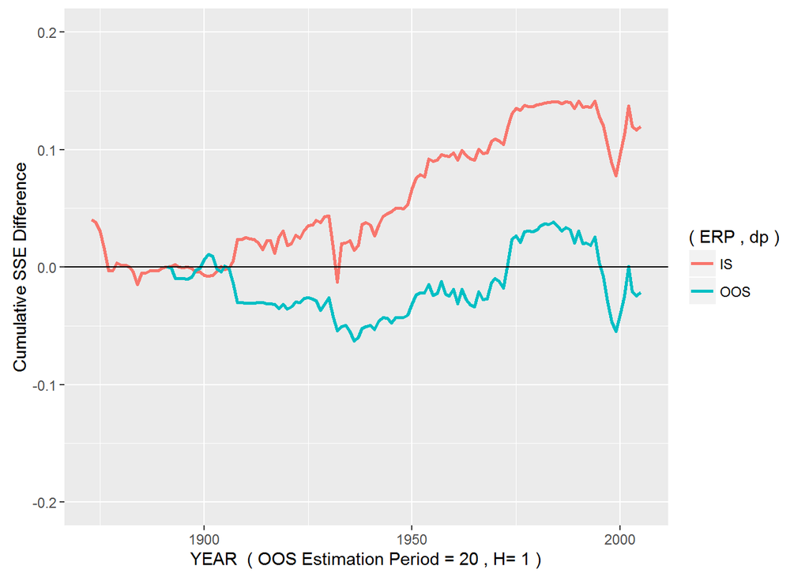

```r
dp_resutls<- Annual_predictability(LHS = "ERP", RHS = "dp",start_date = 1872,end_date = 2005, H=1, OOS_est_period = 20)
dp_resutls$plot_GW2008
```

you can also draw the updated graphs till 2015:

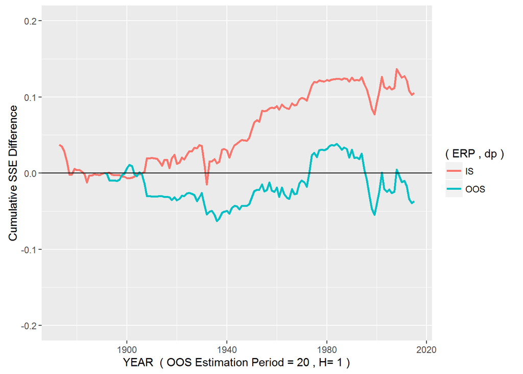

```r
dp_resutls<- Annual_predictability(LHS = "ERP", RHS = "dp",start_date = 1872,end_date = 2015, H=1, OOS_est_period = 20)
dp_resutls$plot_GW2008
```

Make sure that you adjust the start_date when you use different right hand side variables other wise you will get an error. For example the data for “lty” is available from 1919 to 2005 and not from 1872.

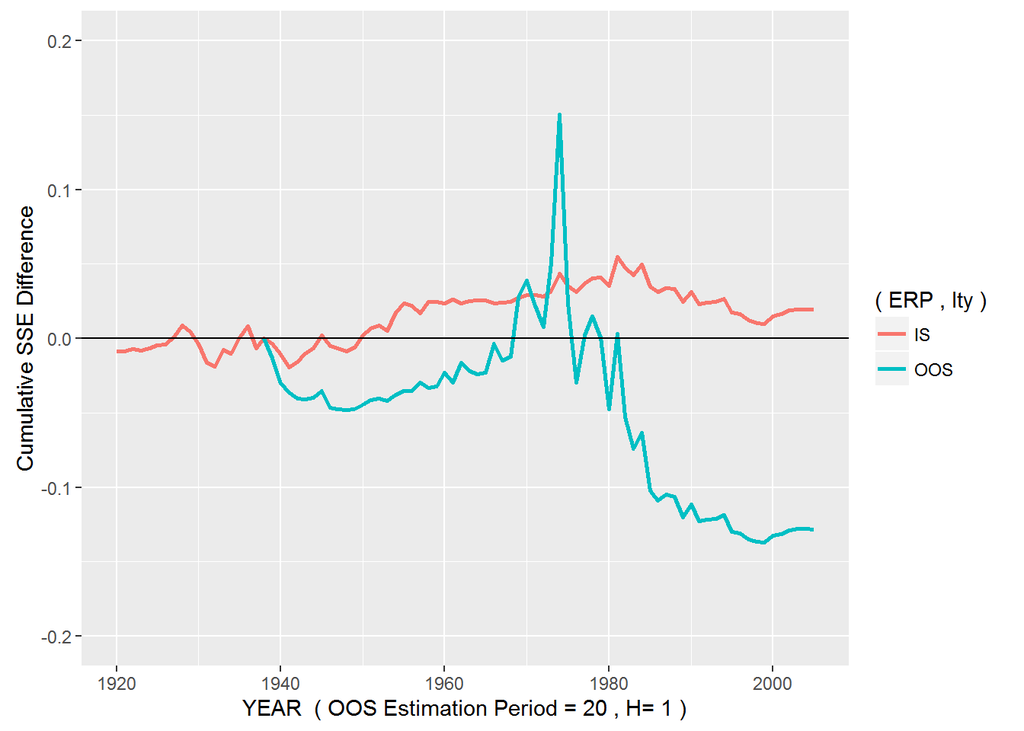

```r
lty_resutls<- Annual_predictability(LHS = "ERP", RHS = "lty",start_date = 1919,end_date = 2005, H=1, OOS_est_period = 20)
lty_resutls$plot_GW2008
```

or the data for “cayp” is available from 1945 to 2005 and not from 1872.

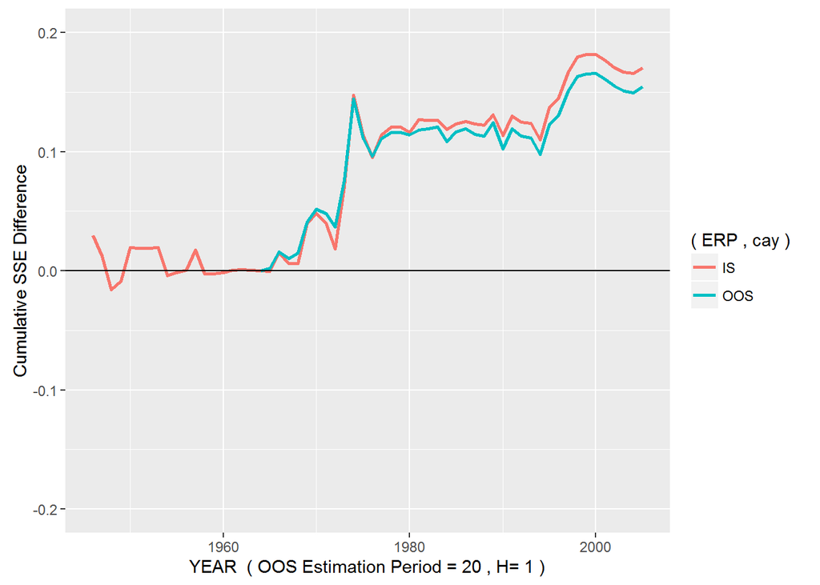

```r
cayp_resutls<- Annual_predictability(LHS = "ERP", RHS = "cay",start_date = 1945,end_date = 2005, H=1, OOS_est_period = 20)
cayp_resutls$plot_GW2008
```

We could also easily replicate graphs like the one in John Cochrane (Discount Rates, JF 2011). For example:

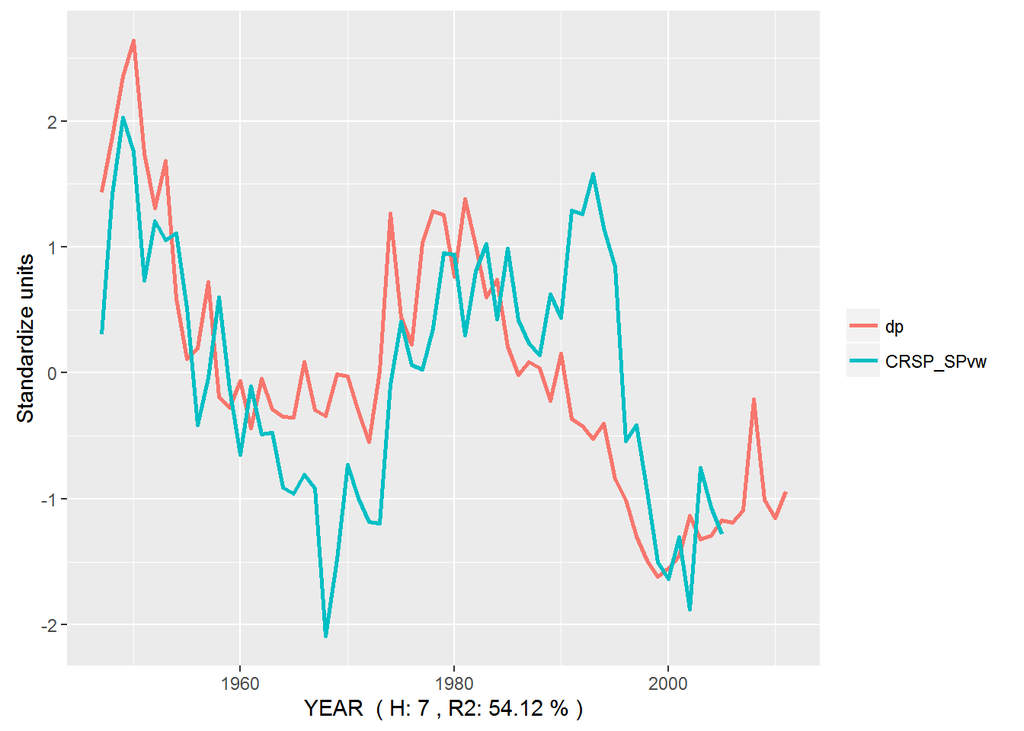

```r
dp_resutls<- Annual_predictability(LHS = "CRSP_SPvw", RHS = "dp",start_date = 1947,end_date = 2011, H=7)
dp_resutls$plot_ll2001
```